# assignment-2

Karan Garg

08/04/2021

# 1 Introduction to the research question and context

I work for **World Health Organisation (WHO)** and they have asked me to analyse the **Stroke_Prediction_Dataset** avaiable [here](https://www.kaggle.com/fedesoriano/stroke-prediction-dataset) .

According to the **World Health Organization (WHO)** stroke is the 2nd leading cause of death globally, responsible for approximately 11% of total deaths. This dataset is used to predict whether a patient is likely to get a stroke based on the input parameters like gender, age, various diseases, and smoking status. Each row in the data provides relavant information about the patient.

- It is a tabular dataset comprising of 5111 rows and 12 columns.

For this assignment I have reduced and cleaned the data according to my research questions. The dimensions of the new data are 1045, 5

The attributes of the new dataset are:

| x |
| --- |
| gender |
| hypertension |
| ever_married |
| work_type |
| stroke |

The Preview of the Dataset is shown below:

| gender | hypertension | ever_married | work_type | stroke |
| --- | --- | --- | --- | --- |
| Male | 0 | Yes | Private | 1 |
| Male | 0 | Yes | Private | 1 |
| Male | 0 | Yes | Private | 1 |
| Male | 1 | Yes | Private | 1 |
| Male | 0 | Yes | Private | 1 |
| Male | 1 | Yes | Private | 1 |

Following are my research questions:

- **What is the ratio of *Strokes* in males depending upon their work type and are they married or not?**
- **What is the ratio of *Hypertension* in males depending upon their work type and are they married or not?**

# 2 Exploratory data analysis

## 2.1 Tabular View

Table 2.1: Tabular View of Ratio of Males having Strokes depending upon their work type and whether they were Marrried or not

| work_type | ever_married | strokes_pct | strokes_cnt |
| --- | --- | --- | --- |
| children | No | 0.0000000 | 0 |
| Never_worked | No | 0.0000000 | 0 |
| Private | No | 0.2870813 | 3 |
| Private | Yes | 5.1674641 | 54 |

The Table 2.1 is achieved after grouping the data according to **Work_Type** and **ever_married** Attribute. After that Summarise is used [**Note** : Summarise used because we used group_by function beforehand and mutate does not work with it,hence Summarise] to find the ratio of strokes in males by using the formula (sum.strokes/no of records)*100.

Table 2.2: Tabular View of Ratio of Males having Hypertension depending upon their work type and whether they were Marrried or not

| work_type | ever_married | hypertension_pct | hypertension_cnt |
| --- | --- | --- | --- |
| children | No | 0.000000 | 0 |
| Never_worked | No | 0.000000 | 0 |
| Private | No | 1.052632 | 11 |
| Private | Yes | 9.569378 | 100 |

The Table 2.2 is achieved after grouping the data according to **Work_Type** and **ever_married** Attribute. After that Summarise is used [**Note** : Summarise used because we used group_by function beforehand and mutate does not work with it,hence Summarise] to find the ratio of hypertension in males by using the formula (sum.hypertension/no of records)*100.

## 2.2 Graphical View

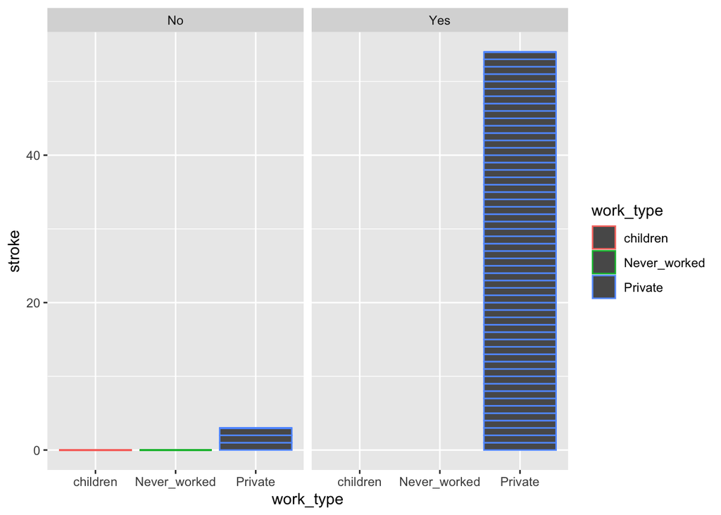

Figure 2.1: Graphical View of Ratio of Males having Strokes

The Figure 2.1 is acheived by plotting a **Histgram** of *stroke* Vs *work_type* attributes and then faceting the *ever_married* attribute. In addition the plot is coloured on the basis of *work_type*.

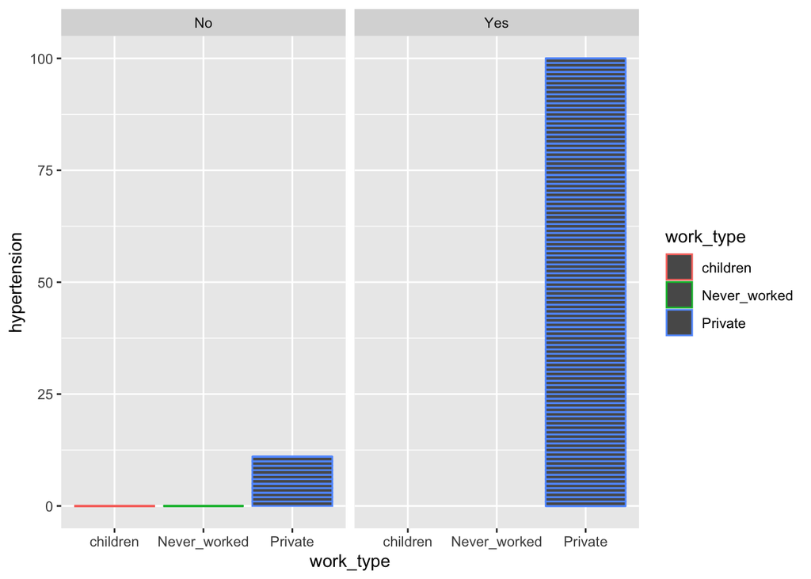

Figure 2.2: Graphical View of Ratio of Males having Hypertension

The Figure 2.2 is acheived by plotting a **Histgram** of *hypertension* Vs *work_type* attributes and then faceting the plot with *ever_married* attribute. In addition the plot is coloured on the basis of *work_type* .

# 3 Conclusion

Hence, We can say that both **Private job** and **marriage** were the key factors for a male to have **stroke** or **hypertension**.